[figure not shown]

# Introduction to Hypothesis Testing on Axis Insurance Dataset

In our journey through the Axis Insurance dataset, we now embark on a critical phase: Hypothesis Testing. This process is pivotal in transforming raw data into meaningful insights, guiding informed decision-making. Here, we apply statistical methods to test hypotheses that stem from our initial explorations and observations during the Exploratory Data Analysis (EDA) phase.

Our focus is to rigorously evaluate specific conjectures regarding various health and demographic factors present in the dataset. These include analyzing the impact of smoking on insurance charges, investigating gender-based differences in BMI, exploring regional variations in smoking habits, and assessing the influence of parenthood on BMI. Each of these inquiries is driven by a clear hypothesis, reflecting our quest to uncover underlying patterns and relationships within the data.

Hypothesis testing in this context serves two key purposes:

Validation of Assumptions: By statistically testing our hypotheses, we validate or refute assumptions made about the dataset. This includes understanding whether observed differences or correlations are statistically significant or merely due to chance.

Guiding Further Analysis and Policy Making: The results from these tests will not only enrich our understanding of the dataset but also provide actionable insights that could guide policy-making, particularly in areas related to health insurance premiums and health-related lifestyle choices.

We will employ various statistical tests, such as the t-test, Chi-Squared test, and ANOVA, each suited to the nature of the data and the specific hypothesis under consideration. The outcome of these tests will be interpreted to draw meaningful conclusions about the Axis Insurance dataset.

Through this rigorous approach, we aim to unveil the statistical truths hidden within the data, thereby enabling Axis Insurance to make data-driven decisions that are both impactful and prudent.

## **By: John Chilton**

### Loading the Libraries and Data

```python
import pandas as pd  # Pandas for data manipulation and analysis
import matplotlib.pyplot as plt  # Matplotlib for plotting graphs
from pandas.plotting import scatter_matrix  # Scatter matrix plot from Pandas
import matplotlib.colors as mcolors  # Matplotlib colors for color customization
import seaborn as sns  # Seaborn for enhanced data visualizations
sns.set_style("whitegrid")  # Set Seaborn plot style to whitegrid
from mpl_toolkits.mplot3d import Axes3D  # Matplotlib's toolkit for 3D plotting
from scipy.stats import ttest_ind  # Independent t-test from SciPy for comparing two group means
from scipy.stats import chi2_contingency  # Chi-squared test from SciPy for categorical data analysis
from scipy.stats import f_oneway  # One-way ANOVA test from SciPy for comparing means across multiple groups
pd.set_option("display.float_format", lambda x: "%.3f" % x)  # Configure Pandas to display floating point numbers with 3 decimals

%matplotlib inline
```

```python
# Importing my drive from Google.
from google.colab import drive
drive.mount('/content/drive')
```

```python
# Loading the csv file from Google.
df = pd.read_csv('/content/drive/MyDrive/lab_mount/insurance.csv')
```

# Data Dictionary –

**Age -** This is an integer indicating the age of the primary beneficiary (excluding those above 64 years, since they are generally covered by the government).

**Sex -** This is the policy holder's gender, either male or female.

**BMI -** This is the body mass index (BMI), which provides a sense of how over or underweight a person is relative to their height. BMI is equal to weight (in kilograms) divided by height (in meters) squared. An ideal BMI is within the range of 18.5 to 24.9.

**Children -** This is an integer indicating the number of children/dependents covered by the insurance plan.

**Smoker -** This is yes or no depending on whether the insured regularly smokes tobacco.

**Region -** This is the beneficiary's place of residence in the U.S., divided into four geographic regions - northeast, southeast, southwest, or northwest.

**Charges -** Individual medical costs billed to health insurance

- Observations
- Sanity Checks

```python
# Head visual of the data set.
df.head(10)
```

|  | age | sex | bmi | children | smoker | region | charges |
| --- | --- | --- | --- | --- | --- | --- | --- |
| 0 | 19 | female | 27.900 | 0 | yes | southwest | 16884.924 |
| 1 | 18 | male | 33.770 | 1 | no | southeast | 1725.552 |
| 2 | 28 | male | 33.000 | 3 | no | southeast | 4449.462 |
| 3 | 33 | male | 22.705 | 0 | no | northwest | 21984.471 |
| 4 | 32 | male | 28.880 | 0 | no | northwest | 3866.855 |
| 5 | 31 | female | 25.740 | 0 | no | southeast | 3756.622 |
| 6 | 46 | female | 33.440 | 1 | no | southeast | 8240.590 |
| 7 | 37 | female | 27.740 | 3 | no | northwest | 7281.506 |
| 8 | 37 | male | 29.830 | 2 | no | northeast | 6406.411 |
| 9 | 60 | female | 25.840 | 0 | no | northwest | 28923.137 |

```python
# Tail visual of the data set.
df.tail(10)
```

|  | age | sex | bmi | children | smoker | region | charges |
| --- | --- | --- | --- | --- | --- | --- | --- |
| 1328 | 23 | female | 24.225 | 2 | no | northeast | 22395.744 |
| 1329 | 52 | male | 38.600 | 2 | no | southwest | 10325.206 |
| 1330 | 57 | female | 25.740 | 2 | no | southeast | 12629.166 |
| 1331 | 23 | female | 33.400 | 0 | no | southwest | 10795.937 |
| 1332 | 52 | female | 44.700 | 3 | no | southwest | 11411.685 |
| 1333 | 50 | male | 30.970 | 3 | no | northwest | 10600.548 |
| 1334 | 18 | female | 31.920 | 0 | no | northeast | 2205.981 |
| 1335 | 18 | female | 36.850 | 0 | no | southeast | 1629.833 |
| 1336 | 21 | female | 25.800 | 0 | no | southwest | 2007.945 |
| 1337 | 61 | female | 29.070 | 0 | yes | northwest | 29141.360 |

```python
# Types of data indicator.
df.dtypes
```

```
age           int64
sex          object
bmi         float64
children      int64
smoker       object
region       object
charges     float64
dtype: object
```

```python
# Data Frame infomation about the data.
df.info()
```

```
<class 'pandas.core.frame.DataFrame'>
RangeIndex: 1338 entries, 0 to 1337
Data columns (total 7 columns):
 #   Column    Non-Null Count  Dtype
---  ------    --------------  -----
 0   age       1338 non-null   int64
 1   sex       1338 non-null   object
 2   bmi       1338 non-null   float64
 3   children  1338 non-null   int64
 4   smoker    1338 non-null   object
 5   region    1338 non-null   object
 6   charges   1338 non-null   float64
dtypes: float64(2), int64(2), object(3)
memory usage: 73.3+ KB
```

```python
# Shape of the data.
df.shape
```

```
(1338, 7)
```

```python
# describing the data.
df.describe().sum().T
```

```
age          1590.257
bmi          1535.242
children     1348.300
charges    122372.968
dtype: float64
```

```python
# Counts the number of missing values in each column of the DataFrame 'df'.
df.isnull().sum()
```

```
age         0
sex         0
bmi         0
children    0
smoker      0
region      0
charges     0
dtype: int64
```

```python
# Checking for duplications.
df.duplicated().sum()
```

```
1
```

```python
# Checking the class of the data frame.
print(type(df))
```

```
<class 'pandas.core.frame.DataFrame'>
```

```python
# Checking correlations with age.
df.corr()['age']
```

```
age        1.000
bmi        0.109
children   0.042
charges    0.299
Name: age, dtype: float64
```

```python
# Checking correlation with bmi.
df.corr()['bmi']
```

```
age        0.109
bmi        1.000
children   0.013
charges    0.198
Name: bmi, dtype: float64
```

```python
# Checking correlation with children.
df.corr()['children']
```

```
age        0.042
bmi        0.013
children   1.000
charges    0.068
Name: children, dtype: float64
```

```python
# Checking correlation with charges.
df.corr()['charges']
```

```
age        0.299
bmi        0.198
children   0.068
charges    1.000
Name: charges, dtype: float64
```

```python
# Inspecting the mean of the data.
df.mean()
```

```
age           39.207
bmi           30.663
children       1.095
charges    13270.422
dtype: float64
```

```python
# Checking the median of the data.
df.median()
```

```
age          39.000
bmi          30.400
children      1.000
charges    9382.033
dtype: float64
```

```python
# Checking the mode of the data.
df.mode()
```

|  | age | sex | bmi | children | smoker | region | charges |
| --- | --- | --- | --- | --- | --- | --- | --- |
| 0 | 18 | male | 32.300 | 0 | no | southeast | 1639.563 |

```python
# Checking the standard deviation.
df.std()
```

```
age           14.050
bmi            6.098
children       1.205
charges    12110.011
dtype: float64
```

```python
# Droping the duplicates. Only 1 so removing it.
df = df.drop_duplicates()
```

```python
# Checking the duplicate is gone.
df.duplicated().sum()
```

```
0
```

## Exploratory Data Analysis (EDA)

## Purpose of EDA

**Discovering Patterns:** One of the primary goals of EDA is to identify patterns within the data. This might include trends, correlations, or groupings. For instance, in your insurance dataset, EDA could reveal correlations between variables like age, BMI, and insurance charges.

**Spotting Anomalies:** EDA helps in detecting anomalies or outliers in the dataset. These are data points that deviate significantly from the rest, which might be indicative of data entry errors, or genuinely unique cases worthy of closer examination.

**Testing Assumptions:** It allows for the testing of assumptions required for model building and hypothesis testing. For instance, assumptions regarding the distribution of variables or the relationship between variables can be visually inspected.

**Informing Model Development and Hypothesis Formulation:** Insights gained from EDA guide the choice of models and the formulation of hypotheses. For example, if a variable shows a non-linear relationship with the outcome, this might suggest the need for transformation or non-linear modeling techniques.

## Key Components of EDA

**Univariate Analysis:** This involves examining each variable individually. For numerical data, this might include looking at measures of central tendency (mean, median) and dispersion (variance, standard deviation). For categorical data, frequency distribution can be insightful.

**Bivariate or Multivariate Analysis:** Here, the relationship between two or more variables is explored. Scatter plots, pair plots, and correlation matrices are common tools used for this type of analysis.

**Data Visualization:** Graphical representations of data are pivotal in EDA. Histograms, box plots, bar charts, and scatter plots are frequently used to visualize data distributions and relationships.

**Handling Missing Values and Outliers:** EDA also involves identifying and treating missing values and outliers in the data. The approach might range from imputation to removal, depending on the extent and nature of these issues.

**Feature Engineering:** This is about creating new variables or modifying existing ones to enhance the model's ability to predict or classify accurately. It's driven by insights gained during EDA.

## Applying EDA to Your Dataset

*A thorough EDA should involve:*

**Distribution of Key Variables:** Examine how variables like BMI, age, and charges are distributed. Are they skewed, normally distributed, or binomial, for instance? Relationship Between Smoking, Region, and Charges: Delve deeper into how smoking status and region might influence insurance charges. This can involve grouping data and looking at aggregated statistics. Gender Differences: Explore how gender might play a role in variables like BMI or insurance charges. Impact of Number of Children: Investigate if and how the number of children affects other variables like charges or BMI.

#### The below functions need to be defined to carry out the Exploratory Data Analysis.

```python
# function to plot a boxplot and a histogram along the same scale.


def histogram_boxplot(data, feature, figsize=(12, 7), kde=False, bins=None):
    """
    Boxplot and histogram combined

    data: dataframe
    feature: dataframe column
    figsize: size of figure (default (12,7))
    kde: whether to the show density curve (default False)
    bins: number of bins for histogram (default None)
    """
    f2, (ax_box2, ax_hist2) = plt.subplots(
        nrows=2,  # Number of rows of the subplot grid= 2
        sharex=True,  # x-axis will be shared among all subplots
        gridspec_kw={"height_ratios": (0.25, 0.75)},
        figsize=figsize,
    )  # creating the 2 subplots
    sns.boxplot(
        data=data, x=feature, ax=ax_box2, showmeans=True, color="violet"
    )  # boxplot will be created and a triangle will indicate the mean value of the column
    sns.histplot(
        data=data, x=feature, kde=kde, ax=ax_hist2, bins=bins, palette="winter"
    ) if bins else sns.histplot(
        data=data, x=feature, kde=kde, ax=ax_hist2
    )  # For histogram
    ax_hist2.axvline(
        data[feature].mean(), color="green", linestyle="--"
    )  # Add mean to the histogram
    ax_hist2.axvline(
        data[feature].median(), color="black", linestyle="-"
    )  # Add median to the histogram
```

```python
# function to create labeled barplots.


def labeled_barplot(data, feature, perc=False, n=None):
    """
    Barplot with percentage at the top

    data: dataframe
    feature: dataframe column
    perc: whether to display percentages instead of count (default is False)
    n: displays the top n category levels (default is None, i.e., display all levels)
    """

    total = len(data[feature])  # length of the column
    count = data[feature].nunique()
    if n is None:
        plt.figure(figsize=(count + 1, 5))
    else:
        plt.figure(figsize=(n + 1, 5))

    plt.xticks(rotation=90, fontsize=15)
    ax = sns.countplot(
        data=data,
        x=feature,
        palette="Paired",
        order=data[feature].value_counts().index[:n].sort_values(),
    )

    for p in ax.patches:
        if perc == True:
            label = "{:.1f}%".format(
                100 * p.get_height() / total
            )  # percentage of each class of the category
        else:
            label = p.get_height()  # count of each level of the category

        x = p.get_x() + p.get_width() / 2  # width of the plot
        y = p.get_height()  # height of the plot

        ax.annotate(
            label,
            (x, y),
            ha="center",
            va="center",
            size=12,
            xytext=(0, 5),
            textcoords="offset points",
        )  # annotate the percentage

    plt.show()  # show the plot
```

```python
# function to plot stacked bar chart.

def stacked_barplot(data, predictor, target):
    """
    Print the category counts and plot a stacked bar chart

    data: dataframe
    predictor: independent variable
    target: target variable
    """
    count = data[predictor].nunique()
    sorter = data[target].value_counts().index[-1]
    tab1 = pd.crosstab(data[predictor], data[target], margins=True).sort_values(
        by=sorter, ascending=False
    )
    print(tab1)
    print("-" * 120)
    tab = pd.crosstab(data[predictor], data[target], normalize="index").sort_values(
        by=sorter, ascending=False
    )
    tab.plot(kind="bar", stacked=True, figsize=(count + 1, 5))
    plt.legend(
        loc="lower left", frameon=False,
    )
    plt.legend(loc="upper left", bbox_to_anchor=(1, 1))
    plt.show()
```

```python
### Function to plot distributions.

def distribution_plot_wrt_target(data, predictor, target):

    fig, axs = plt.subplots(2, 2, figsize=(12, 10))

    target_uniq = data[target].unique()

    axs[0, 0].set_title("Distribution of target for target=" + str(target_uniq[0]))
    sns.histplot(
        data=data[data[target] == target_uniq[0]],
        x=predictor,
        kde=True,
        ax=axs[0, 0],
        color="teal",
    )

    axs[0, 1].set_title("Distribution of target for target=" + str(target_uniq[1]))
    sns.histplot(
        data=data[data[target] == target_uniq[1]],
        x=predictor,
        kde=True,
        ax=axs[0, 1],
        color="orange",
    )

    axs[1, 0].set_title("Boxplot w.r.t target")
    sns.boxplot(data=data, x=target, y=predictor, ax=axs[1, 0], palette="gist_rainbow")

    axs[1, 1].set_title("Boxplot (without outliers) w.r.t target")
    sns.boxplot(
        data=data,
        x=target,
        y=predictor,
        ax=axs[1, 1],
        showfliers=False,
        palette="gist_rainbow",
    )

    plt.tight_layout()
    plt.show()
```

### Univariate Analysis

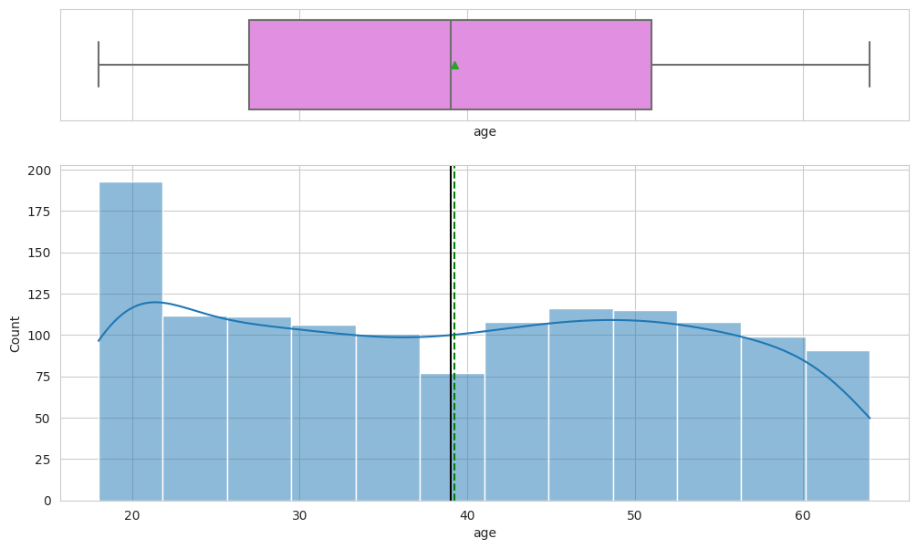

```python
# Histogram and Boxplot of age.
histogram_boxplot(df, "age", kde=True);
```

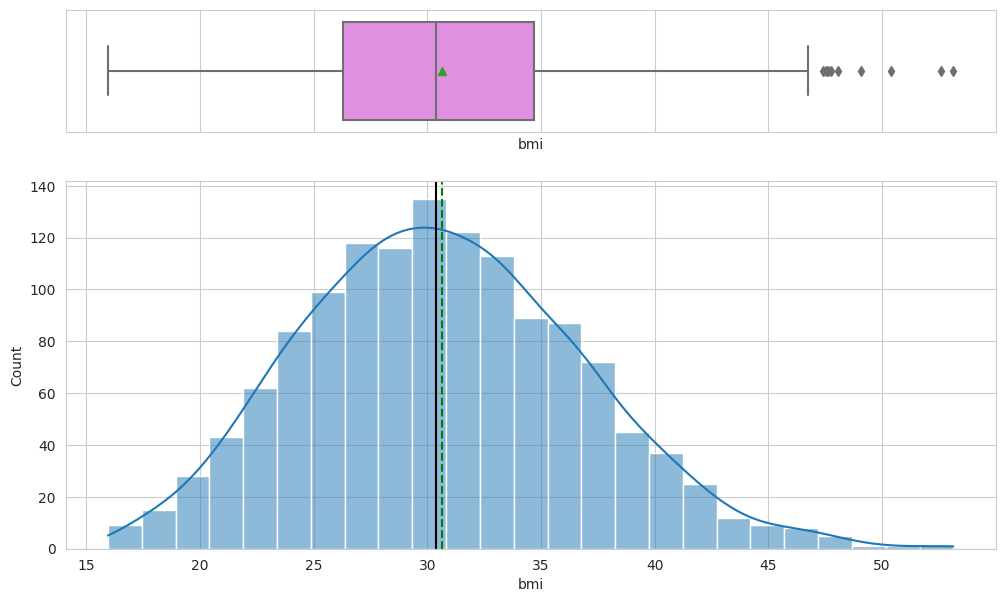

```python
# Histogram and Boxplot of bmi.
histogram_boxplot(df, "bmi", kde=True);
```

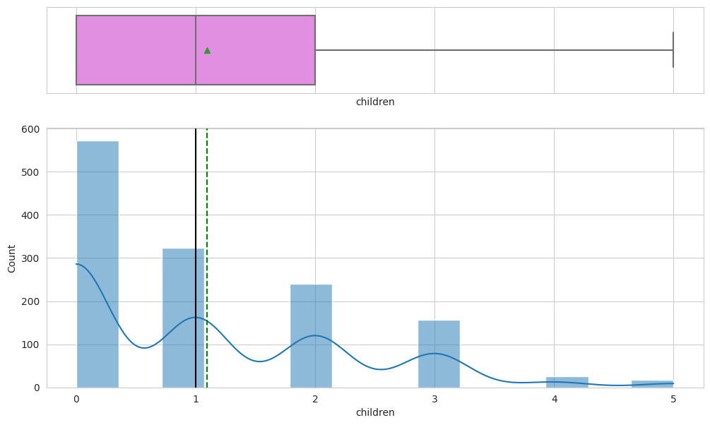

```python
# Histogram and Boxplot of children.
histogram_boxplot(df, "children", kde=True);
```

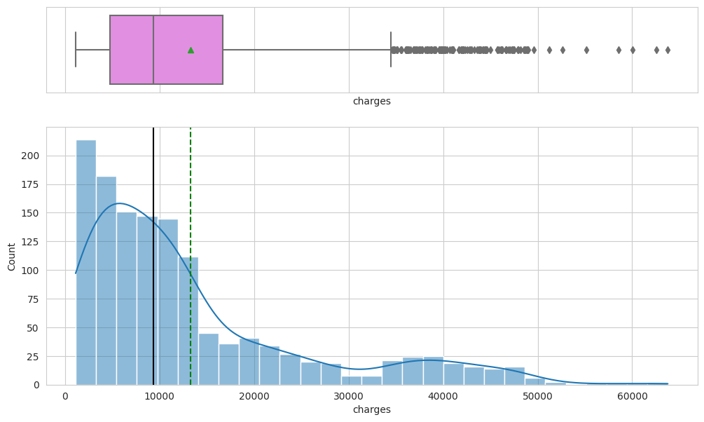

```python
# Histogram and Boxplot of charges.
histogram_boxplot(df, "charges", kde=True);
```

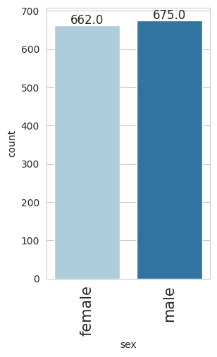

```python
# Labeled Barplot of sex.
labeled_barplot(df, "sex");
```

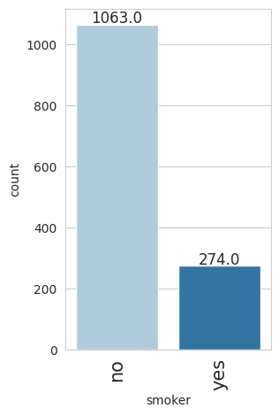

```python
# Labeled Barplot of smoker.
labeled_barplot(df, "smoker");
```

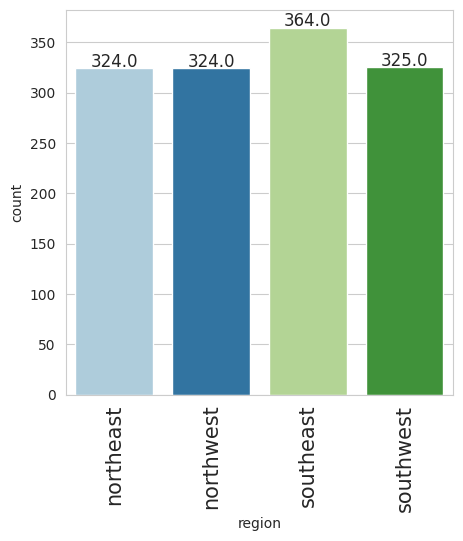

```python
# Labeled Barplot of region.
labeled_barplot(df, "region");
```

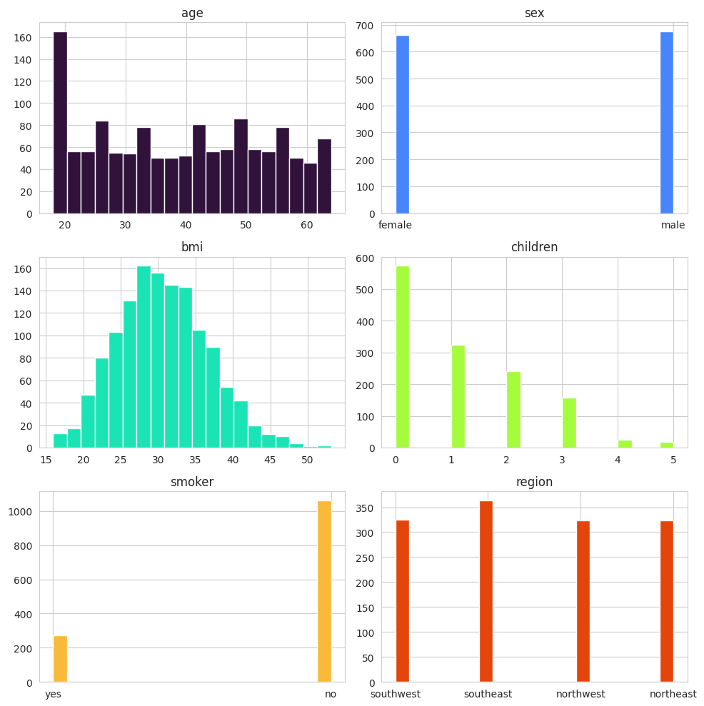

```python
# Define the number of rows and columns for the subplots.
n_rows, n_cols = df.shape[1] // 2, 2

# Create a figure and axes with the specified size
fig, axes = plt.subplots(nrows=n_rows, ncols=n_cols, figsize=(10, 10))

# Flatten the axes array for easy indexing
axes = axes.flatten()

# Loop through the DataFrame's columns and create a histogram for each
for ax, column in zip(axes, df.columns):
    ax.hist(df[column], bins=20, color=plt.cm.turbo(np.linspace(0, 1, df.shape[1]))[df.columns.get_loc(column)])
    ax.set_title(column)

# Adjust the layout and display the plot
plt.tight_layout()
plt.show()
```

### Bivariate Distributions

**Let's see the attributes that have a strong correlation with each other**

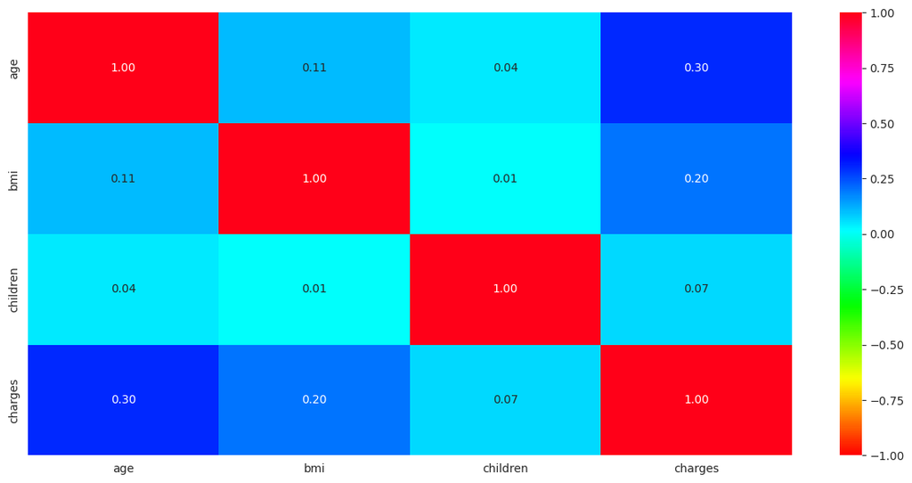

```python
# Heatmap of the data set to look for corrilations in the data.
plt.figure(figsize=(15, 7))
sns.heatmap(df.corr(), annot=True, vmin=-1, vmax=1, fmt=".2f", cmap="hsv")
plt.show();
```

```
smoker    no  yes   All
sex
All     1063  274  1337
male     516  159   675
female   547  115   662
------------------------------------------------------------------------------------------------------------------------
```

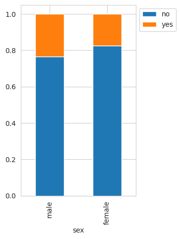

```python
# Stacked Barplot of sex vs smoker.
stacked_barplot(df, "sex", "smoker");
```

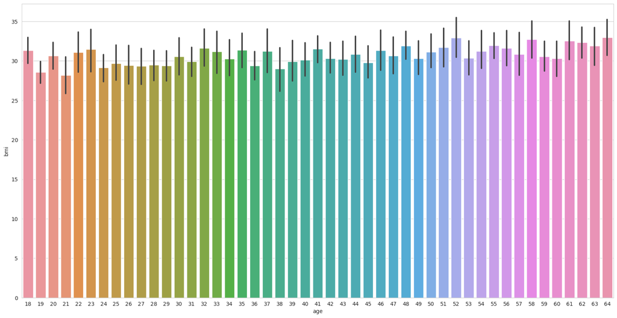

```python
# Barplot of age vs. bmi.

# Set the figure size
plt.figure(figsize=(20, 10))  # Adjust the values as desired

# Create the bar plot
sns.barplot(data=df, x='age', y='bmi')

# Show the plot
plt.show();
```

```
region  northeast  northwest  southeast  southwest   All
smoker
All           324        324        364        325  1337
no            257        266        273        267  1063
yes            67         58         91         58   274
------------------------------------------------------------------------------------------------------------------------
```

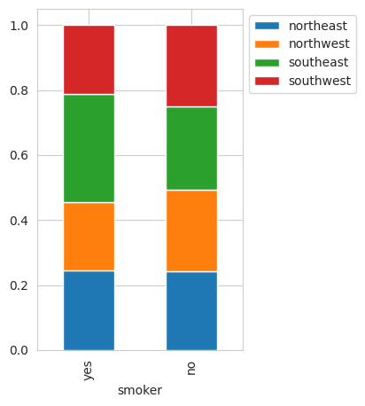

```python
# Stacked Barplot of smoker and region.
stacked_barplot(df, "smoker", "region");
```

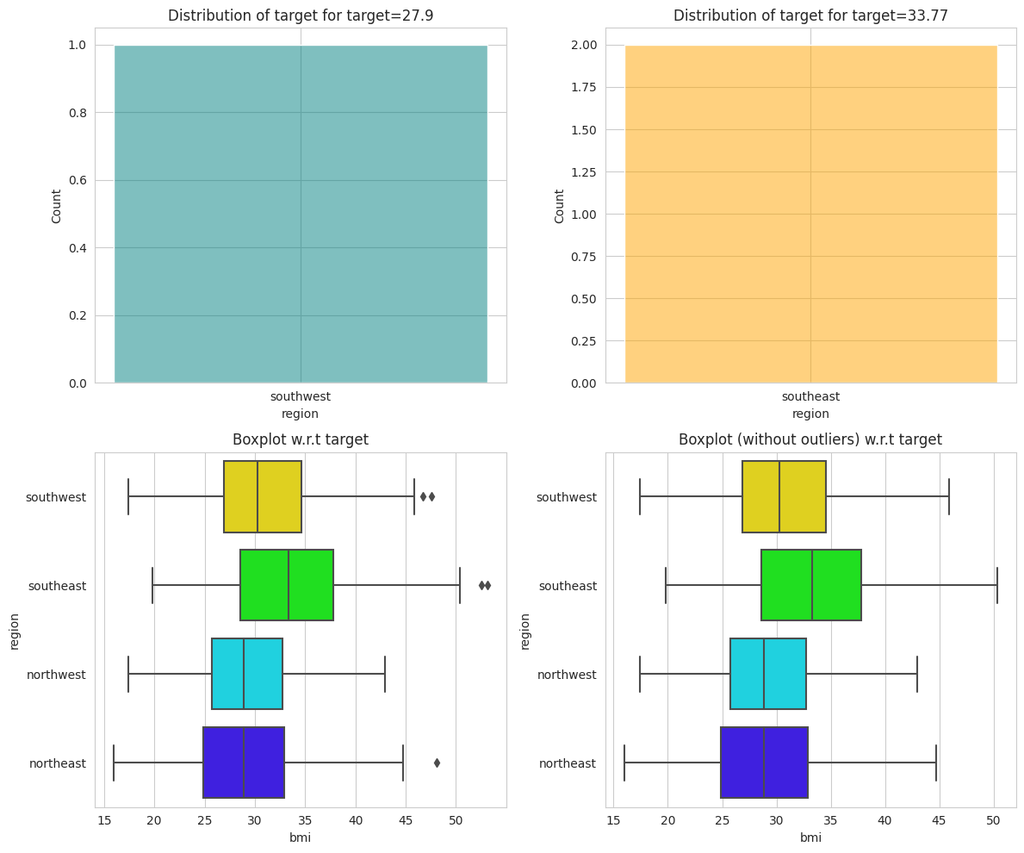

```python
# Distribution plot of region vs bmi.
distribution_plot_wrt_target(df, "region", "bmi");
```

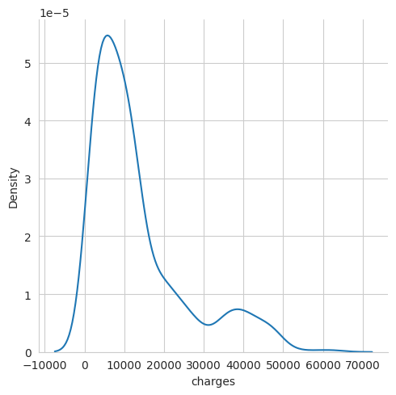

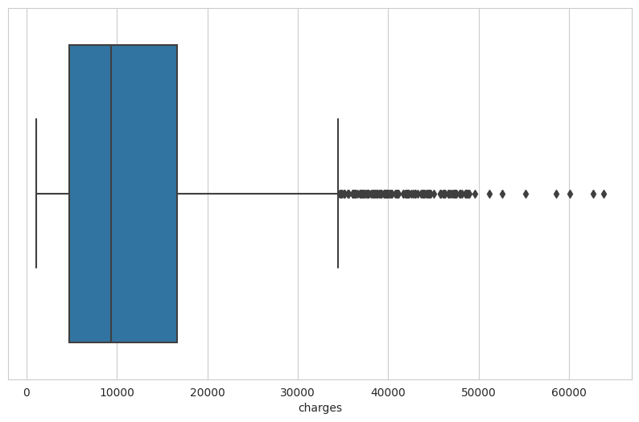

```python
# Displot and Boxplot of charges.

# KDE Plot for 'charges'
plt.figure(figsize=(10,6))  # Adjust the figure size as desired
sns.displot(data=df, x='charges', kind='kde')
plt.show()

# Box Plot for 'charges'
plt.figure(figsize=(10,6))  # Adjust the figure size as desired
sns.boxplot(data=df, x='charges')
plt.show();
```

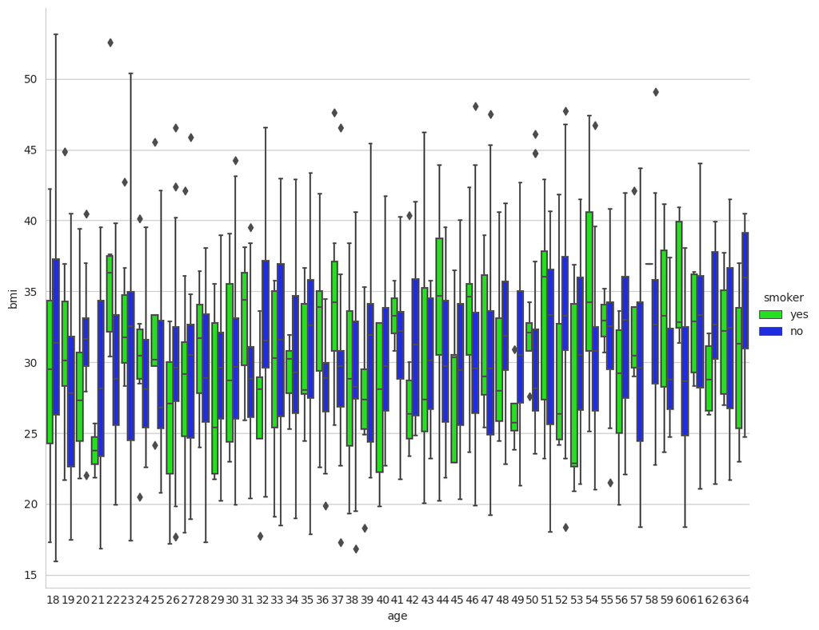

```python
# Catplot of bmi vs. smoker.
sns.catplot(data=df, x='age', y='bmi', hue='smoker', kind='box', height=8, aspect=1.2, palette='hsv');
```

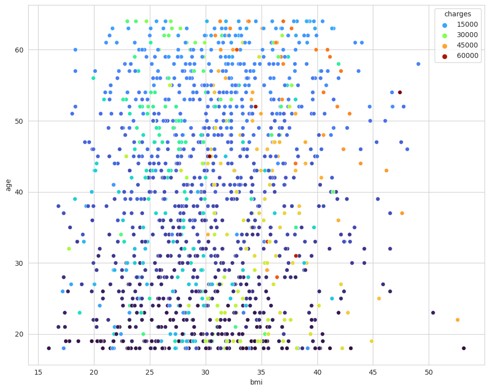

```python
# Scatterplot of bmi, age, and charges.

plt.figure(figsize=(10, 8))  # Adjust the values (10, 8) as needed

# Scatterplot with color based on 'Education'
sns.scatterplot(data=df, x='bmi', y='age', hue='charges', palette='turbo')

# Adjust layout
plt.tight_layout()

# Display the plot
plt.show();
```

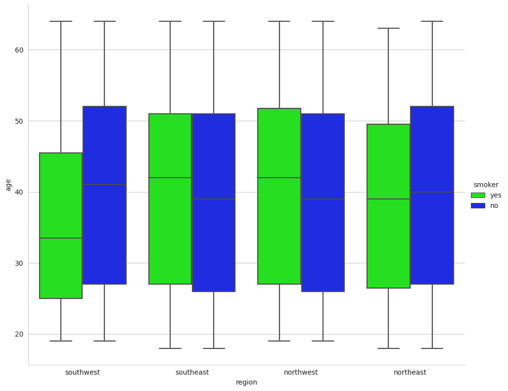

```python
# Catplot of region, age, and smoker.
sns.catplot(data=df, x='region', y='age', hue='smoker', kind='box', height=8, aspect=1.2, palette='hsv');
```

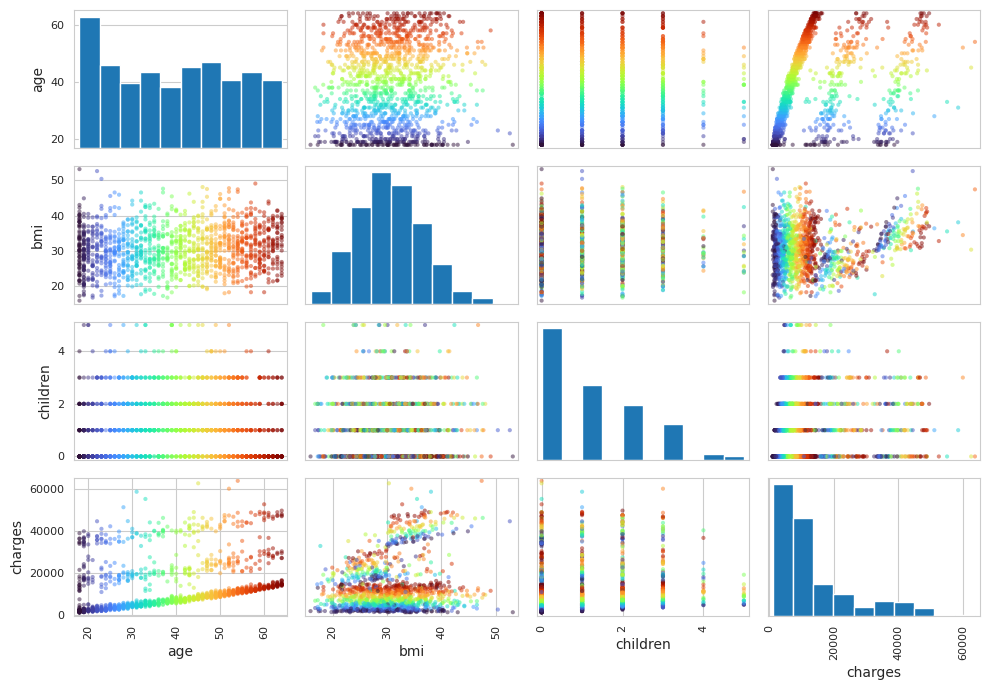

```python
# List of attributes you want to view pairwise relationships for.
attributes = ["age", "bmi", "sex", "children", "charges"]

# Normalize 'age' for color mapping
norm = mcolors.Normalize(vmin=df['age'].min(), vmax=df['age'].max())

# Create a color mapping based on 'age'
colors = plt.cm.turbo(norm(df['age']))

# Using the scatter_matrix function to plot pairwise relationships
scatter_matrix(df[attributes], figsize=(10, 7), color=colors)

# Tightening the layout and showing the plot
plt.tight_layout()
plt.show();
```

[figure not shown]

```python
# Peaks and valley's  3d visual.
x = np.linspace(-3, 3, 101)
y = np.linspace(-3, 3, 101)
x, y = np.meshgrid(x, y)
z = 3 * (1 - x)**2 * np.exp(-(x**2) - (y + 1)**2) - 10 * (x / 5 - x**3 - y**5) * np.exp(-x**2 - y**2) - 1/3 * np.exp(-(x + 1)**2 - y**2)

# Create a 3D plot
fig = plt.figure()
ax = fig.add_subplot(111, projection='3d')
surf = ax.plot_surface(x, y, z, cmap='hsv')  # You can change 'viridis' to any other colormap

# Show the plot
plt.show();
```

## Dealing with Outliers

```python
# Calculate Q1, Q3, and IQR for column bmi.
Q1 = df['bmi'].quantile(0.25)
Q3 = df['bmi'].quantile(0.75)
IQR = Q3 - Q1

# Define minimum and maximum thresholds and filter out outliers
min_threshold = Q1 - 1.5 * IQR
max_threshold = Q3 + 1.5 * IQR
df_filtered = df[(df['bmi'] >= min_threshold) & (df['bmi'] <= max_threshold)]
```

```python
# Calculate Q1, Q3, and IQR for numerical column charges.
Q1 = df['charges'].quantile(0.25)
Q3 = df['charges'].quantile(0.75)
IQR = Q3 - Q1

# Define minimum and maximum thresholds and filter out outliers
min_threshold = Q1 - 1.5 * IQR
max_threshold = Q3 + 1.5 * IQR
df_filtered = df[(df['charges'] >= min_threshold) & (df['charges'] <= max_threshold)]
```

```python
# Calculate Q1, Q3, and IQR for a numerical column bmi.
Q1 = df['bmi'].quantile(0.25)
Q3 = df['bmi'].quantile(0.75)
IQR = Q3 - Q1

print(f"Q1: {Q1}")
print(f"Q3: {Q3}")
print(f"IQR: {IQR}")
```

```
Q1: 26.29
Q3: 34.7
IQR: 8.410000000000004
```

```python
# Calculate Q1, Q3, and IQR for a numerical column age.
Q1 = df['age'].quantile(0.25)
Q3 = df['age'].quantile(0.75)
IQR = Q3 - Q1

print(f"Q1: {Q1}")
print(f"Q3: {Q3}")
print(f"IQR: {IQR}")
```

```
Q1: 27.0
Q3: 51.0
IQR: 24.0
```

# Hypothesis Tests

## Introduction to Hypothesis Testing

In this section, we delve into the heart of statistical analysis by performing hypothesis testing on various aspects of our insurance dataset. Hypothesis testing is a fundamental tool in statistics that allows us to make inferences about a population based on sample data. Through this method, we test assumptions and draw conclusions about the relationships between different variables within our dataset.

Our primary objective here is to investigate key hypotheses that are crucial to understanding the dynamics of health insurance and related factors. We will be exploring several critical questions: Does smoking status significantly impact insurance charges? Is there a difference in BMI based on gender or the number of children a woman has? Do the proportions of smokers vary significantly across different regions? Each of these questions will be addressed using appropriate statistical tests such as t-tests, Chi-Squared tests, and ANOVA, depending on the nature of the data and the specific hypothesis being tested.

This rigorous approach enables us to move beyond mere observations to statistically sound conclusions. By the end of this section, we will have a clearer, evidence-backed understanding of the patterns and relationships within our dataset, leading to insights that are both valuable and actionable.

## P-Test for smoker and charges

```python
# Assuming 'smoker' is the column indicating smoking status.
# and 'charges' is the column for insurance charges.

# Separate the groups
smokers = df[df['smoker'] == 'yes']['charges']
non_smokers = df[df['smoker'] == 'no']['charges']

# Perform the t-test
t_stat, p_value = ttest_ind(smokers, non_smokers)

# Display the results
print(f'T-statistic: {t_stat}')
print(f'P-value: {p_value}')

# Interpretation
if p_value < 0.05:
    print("There's a statistically significant difference between the two groups.")
else:
    print("There's no statistically significant difference between the two groups.")
```

```
T-statistic: 46.64479459840305
P-value: 1.4067220949376498e-282
There's a statistically significant difference between the two groups.
```

T-Statistic: The t-statistic is 46.645, which is quite high. This indicates a substantial difference between the means of the two groups being compared. A higher t-statistic typically suggests a greater difference between groups.

Statistical Significance: Given the extremely low p-value, you can confidently reject the null hypothesis, which assumes no difference between the two groups. This implies that there is a statistically significant difference between the groups you're comparing.

The results clearly indicate a significant difference, but without context (such as what these groups represent or what variable is being compared), it's difficult to interpret the practical implications. However, the statistical evidence strongly suggests that the two groups differ in terms of the measured variable. It's also important to consider the effect size and practical significance of this finding, especially in cases where the statistical significance is very clear, as it is here.

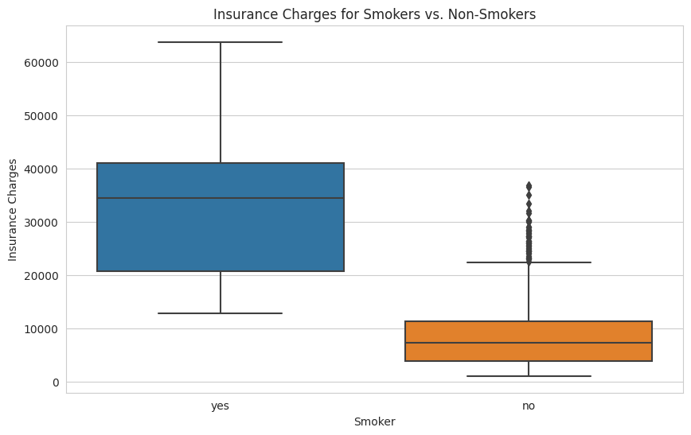

```python
# PLotting visual for the above P-Test.
plt.figure(figsize=(10, 6))
sns.boxplot(x='smoker', y='charges', data=df)

plt.title('Insurance Charges for Smokers vs. Non-Smokers')
plt.xlabel('Smoker')
plt.ylabel('Insurance Charges')
plt.show();
```

## P-Test for sex and bmi

```python
# Sex is the column indicating gender and 'bmi' is the column for bmi.

# Separate the groups
males_bmi = df[df['sex'] == 'male']['bmi']
females_bmi = df[df['sex'] == 'female']['bmi']

# Perform the t-test
t_stat, p_value = ttest_ind(males_bmi, females_bmi)

# Display the results
print(f'T-statistic: {t_stat}')
print(f'P-value: {p_value}')

# Interpretation
if p_value < 0.05:
    print("There's a statistically significant difference between the BMIs of males and females.")
else:
    print("There's no statistically significant difference between the BMIs of males and females.")
```

```
T-statistic: 1.6970672301298684
P-value: 0.08991704324931137
There's no statistically significant difference between the BMIs of males and females.
```

T-Statistic: The t-statistic value is 1.697. This value represents the calculated difference between the two sample means (male and female BMIs) expressed in terms of the standard error. A higher absolute value of the t-statistic indicates a greater difference between the groups.

P-Value: The p-value is approximately 0.0899. This value indicates the probability of observing a t-statistic as extreme as, or more extreme than, the one calculated, assuming that there is no true difference in the BMIs between males and females (null hypothesis).

Statistical Significance: The common threshold for declaring statistical significance is a p-value less than 0.05. Since your p-value (0.0899) is greater than this threshold, you do not have sufficient evidence to reject the null hypothesis. Therefore, you conclude that there is no statistically significant difference in BMI between males and females in your dataset.

In summary, based on your t-test, there's no evidence to suggest a significant difference in BMI between the male and female groups in the dataset you're analyzing. This conclusion is based on the statistical threshold typically used; however, it's important to consider other factors such as the effect size and the sample size, as they can also provide valuable insights into the practical significance of your findings.

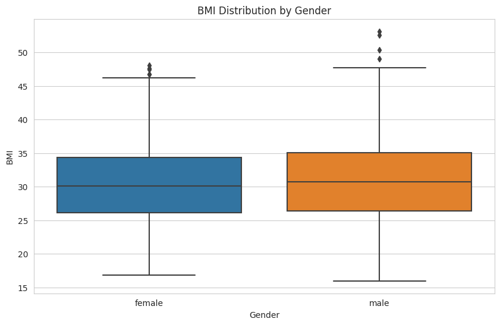

```python
# Plotting the above P-Test.
plt.figure(figsize=(10, 6))
sns.boxplot(x='sex', y='bmi', data=df)

plt.title('BMI Distribution by Gender')
plt.xlabel('Gender')
plt.ylabel('BMI')
plt.show();
```

## Chi-Squared Test region and smoker

```python
#  Region is the column for regions and smoker for smoking status.
contingency_table = pd.crosstab(df['region'], df['smoker'])

print("Contingency Table:")
print(contingency_table)

# Perform the Chi-Squared test
chi2, p_value, dof, expected = chi2_contingency(contingency_table)

# Display the results
print("\nChi-Squared Test Results:")
print(f"Chi-Squared value: {chi2}")
print(f"P-value: {p_value}")
print(f"Degrees of Freedom: {dof}")
print("\nExpected Frequencies:")
print(expected)

# Interpretation
if p_value < 0.05:
    print("\nThere's a statistically significant difference in the proportion of smokers across different regions.")
else:
    print("\nThere's no statistically significant difference in the proportion of smokers across different regions.")
```

```
Contingency Table:
smoker      no  yes
region
northeast  257   67
northwest  266   58
southeast  273   91
southwest  267   58

Chi-Squared Test Results:
Chi-Squared value: 7.27790254132191
P-value: 0.06354826573182334
Degrees of Freedom: 3

Expected Frequencies:
[[257.60059835  66.39940165]
 [257.60059835  66.39940165]
 [289.40314136  74.59685864]
 [258.39566193  66.60433807]]

There's no statistically significant difference in the proportion of smokers across different regions.
```

To summarize:

Chi-Squared Value: 7.2779. This is a measure of the difference between the observed and expected frequencies in your contingency table. P-Value: 0.06355. Since this value is greater than 0.05, you do not have enough evidence to reject the null hypothesis, which assumes no association between region and smoking status. Degrees of Freedom: 3. This is calculated based on the number of categories in each variable (4 regions - 1) * (2 smoker statuses - 1). Expected Frequencies: These are the frequencies that would be expected if there were no association between the region and smoking status. Your observed frequencies are relatively close to these expected frequencies, further supporting the lack of a significant association. In conclusion, your analysis indicates that the smoking habits are fairly consistent across regions in your dataset, without a significant variation in the proportion of smokers.

# Female with children bmi ANOVA Test

Grouping the Data: You would first segregate the women in your dataset into three groups based on the number of children they have: no children, one child, and two children.

Conducting ANOVA: The ANOVA test will compare the means of these three groups. It essentially looks at the variance within each group and between the groups to determine if any significant differences exist.

Interpreting the Results:

F-Statistic: ANOVA produces an F-statistic, which is the ratio of the variance between the groups to the variance within the groups. A higher value indicates a greater likelihood of a significant difference in means. P-Value: This will tell you whether the observed differences in means could have occurred by chance. A p-value less than 0.05 typically indicates that there is at least one group mean that is significantly different from the others. Post-Hoc Testing: If the ANOVA is significant, it only tells you that there is a difference, but not which groups are different from each other. For that, post-hoc tests like Tukey’s HSD (Honestly Significant Difference) are used.

```python
# Filter the dataset for women.
women_df = df[df['sex'] == 'female']

# Group by the number of children (0, 1, 2)
group_0 = women_df[women_df['children'] == 0]['bmi']
group_1 = women_df[women_df['children'] == 1]['bmi']
group_2 = women_df[women_df['children'] == 2]['bmi']

# Perform ANOVA
f_stat, p_value = f_oneway(group_0, group_1, group_2)

# Display the results
print(f'F-Statistic: {f_stat}')
print(f'P-value: {p_value}')

# Interpretation
if p_value < 0.05:
    print("At least one group mean is significantly different.")
else:
    print("No significant difference between the group means.")
```

```
F-Statistic: 0.3344720147757968
P-value: 0.7158579926754841
No significant difference between the group means.
```

Based on the results of your ANOVA test:

F-Statistic: The F-statistic value is approximately 0.334. This value is relatively low, suggesting that the variance between the group means (women with 0, 1, and 2 children) is not much larger than the variance within each group.

P-Value: The p-value is approximately 0.716, which is much higher than the conventional threshold for statistical significance (Usually p < 0.05).

Conclusion: Since the p-value is greater than 0.05, you do not have sufficient evidence to reject the null hypothesis of the ANOVA test. The null hypothesis in this case states that there are no differences between the group means. Therefore, your analysis concludes that there is no statistically significant difference in the mean BMI of women with no children, one child, and two children in your dataset.

This means, from a statistical standpoint, the number of children does not appear to significantly affect the mean BMI among these groups of women in the data you analyzed.

# **Conclusion**

In this analysis, we explored several key aspects of the insurance dataset to understand different health and demographic factors. Specifically, we focused on the relationships between smoking status, region, gender, the number of children, and their potential impacts on BMI and insurance charges.

**Key Findings:**

Smoking Status and Insurance Charges: A t-test revealed a statistically significant difference in insurance charges between smokers and non-smokers. This indicates that smoking status is a significant factor in determining insurance charges.

BMI of Males vs. Females: Our analysis using a t-test showed no significant difference in the BMI between males and females, suggesting that gender does not play a significant role in BMI variations in this dataset.

Proportion of Smokers Across Regions: A Chi-Squared test was conducted to examine if the proportion of smokers differs significantly across different regions. The results showed no significant difference, indicating that smoking habits are fairly consistent across regions in this dataset.

BMI Variation with the Number of Children: An ANOVA test was performed to determine if women's BMI varies significantly with the number of children (0, 1, or 2). The analysis concluded that there is no significant difference in the mean BMI among these groups.

These findings provide valuable insights into the factors that influence health insurance charges and BMI. The significant impact of smoking status on insurance charges underscores the importance of lifestyle choices in health-related financial planning. The lack of significant gender differences in BMI and the consistency in smoking habits across regions highlight the uniformity in these aspects among the dataset's demographics. The analysis regarding the number of children and BMI suggests that, within this dataset, maternal health as reflected in BMI does not significantly vary with a small number of children.

**Future Work**

Future analyses could explore the dataset further by:

Investigating other variables such as age, region, and individual health indicators. Conducting multivariate analysis to understand the combined effect of different variables on insurance charges and health metrics. Exploring potential non-linear relationships or interactions between variables. This study provides a foundational understanding of key factors in health insurance data, paving the way for more comprehensive and nuanced analyses in the future.